# Exploring a Red Wine Data Set by Julio Uribe

```
## [1] "C:/Users/Jules/Desktop/Nano/EDA Project"
```

### Introduction

This report explores a data set of red wine containing approximately 1600 different kinds of wine. I’m a fan of red wine but wouldn’t consider myself very knowledgeable. The purpose of this exploration is to learn more about what chemical qualities influence overall quality of wine, rated by experts. Perhaps we can take our conclusions to the real world and do some in field testing. Before exploring the data, I think that residual sugar, alcohol level, and acidity will have the most influence on quality of wine. overall I want to learn what affects the quality of wine so that I can make more informed predictions at what kind of wine I or others would enjoy

# Univariate Plots Section

```
##  [1] "X"                    "fixed.acidity"        "volatile.acidity"
##  [4] "citric.acid"          "residual.sugar"       "chlorides"
##  [7] "free.sulfur.dioxide"  "total.sulfur.dioxide" "density"
## [10] "pH"                   "sulphates"            "alcohol"
## [13] "quality"
```

```
##        X          fixed.acidity   volatile.acidity  citric.acid
##  Min.   :   1.0   Min.   : 4.60   Min.   :0.1200   Min.   :0.000
##  1st Qu.: 400.5   1st Qu.: 7.10   1st Qu.:0.3900   1st Qu.:0.090
##  Median : 800.0   Median : 7.90   Median :0.5200   Median :0.260
##  Mean   : 800.0   Mean   : 8.32   Mean   :0.5278   Mean   :0.271
##  3rd Qu.:1199.5   3rd Qu.: 9.20   3rd Qu.:0.6400   3rd Qu.:0.420
##  Max.   :1599.0   Max.   :15.90   Max.   :1.5800   Max.   :1.000
##  residual.sugar     chlorides       free.sulfur.dioxide
##  Min.   : 0.900   Min.   :0.01200   Min.   : 1.00
##  1st Qu.: 1.900   1st Qu.:0.07000   1st Qu.: 7.00
##  Median : 2.200   Median :0.07900   Median :14.00
##  Mean   : 2.539   Mean   :0.08747   Mean   :15.87
##  3rd Qu.: 2.600   3rd Qu.:0.09000   3rd Qu.:21.00
##  Max.   :15.500   Max.   :0.61100   Max.   :72.00
##  total.sulfur.dioxide    density             pH          sulphates
##  Min.   :  6.00       Min.   :0.9901   Min.   :2.740   Min.   :0.3300
##  1st Qu.: 22.00       1st Qu.:0.9956   1st Qu.:3.210   1st Qu.:0.5500
##  Median : 38.00       Median :0.9968   Median :3.310   Median :0.6200
##  Mean   : 46.47       Mean   :0.9967   Mean   :3.311   Mean   :0.6581
##  3rd Qu.: 62.00       3rd Qu.:0.9978   3rd Qu.:3.400   3rd Qu.:0.7300
##  Max.   :289.00       Max.   :1.0037   Max.   :4.010   Max.   :2.0000
##     alcohol         quality
##  Min.   : 8.40   Min.   :3.000
##  1st Qu.: 9.50   1st Qu.:5.000
##  Median :10.20   Median :6.000
##  Mean   :10.42   Mean   :5.636
##  3rd Qu.:11.10   3rd Qu.:6.000
##  Max.   :14.90   Max.   :8.000
```

```
##     X fixed.acidity volatile.acidity citric.acid residual.sugar chlorides
## 1   1           7.4             0.70        0.00            1.9     0.076
## 2   2           7.8             0.88        0.00            2.6     0.098
## 3   3           7.8             0.76        0.04            2.3     0.092
## 4   4          11.2             0.28        0.56            1.9     0.075
## 5   5           7.4             0.70        0.00            1.9     0.076
## 6   6           7.4             0.66        0.00            1.8     0.075
## 7   7           7.9             0.60        0.06            1.6     0.069
## 8   8           7.3             0.65        0.00            1.2     0.065
## 9   9           7.8             0.58        0.02            2.0     0.073
## 10 10           7.5             0.50        0.36            6.1     0.071
##    free.sulfur.dioxide total.sulfur.dioxide density   pH sulphates alcohol
## 1                   11                   34  0.9978 3.51      0.56     9.4
## 2                   25                   67  0.9968 3.20      0.68     9.8
## 3                   15                   54  0.9970 3.26      0.65     9.8
```

[output cut: 18 more lines]

Our data set contains 12 variables plus an identifier varible with almost 1600 observations. These variables are not easily observed in a kitchen. For most of these variables you’d need a chemistry set to extract the values. Let’s remove the x variable to focus on the other 12 variables.

```
##    Min. 1st Qu.  Median    Mean 3rd Qu.    Max.
##   3.000   5.000   6.000   5.636   6.000   8.000
```

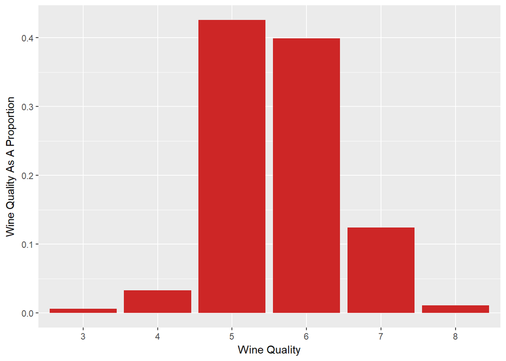

Wine quality distribution falls between a low of 3 and high of 8. We have a mean of 5.64 and a median of 6.00. Our max is 8 and min is 3. Most wine is rated either as a 5 or 6. When looking at the histogram of wine quality as a proportion we see that a little more than 40% of wine is rated a 5, about 40% is rated a 6, about 10% is rated a 7, and the rest of the values scatter out to 3, 4, and 8.

```
##    Min. 1st Qu.  Median    Mean 3rd Qu.    Max.
##    8.40    9.50   10.20   10.42   11.10   14.90
```

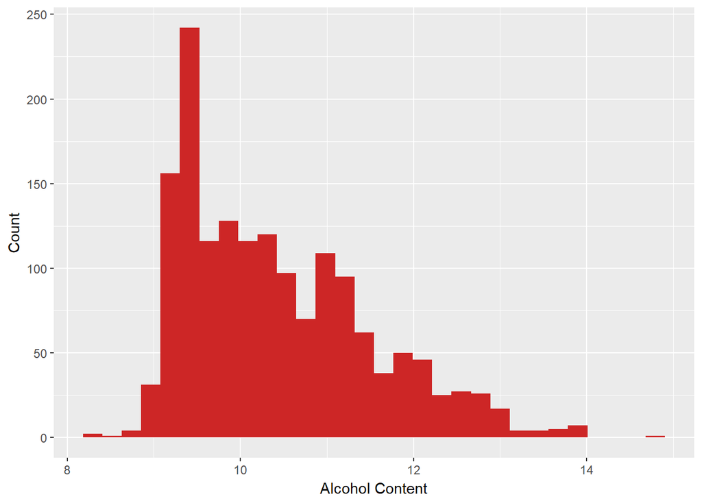

```
##    Min. 1st Qu.  Median    Mean 3rd Qu.    Max.
##   0.900   1.900   2.200   2.539   2.600  15.500
```

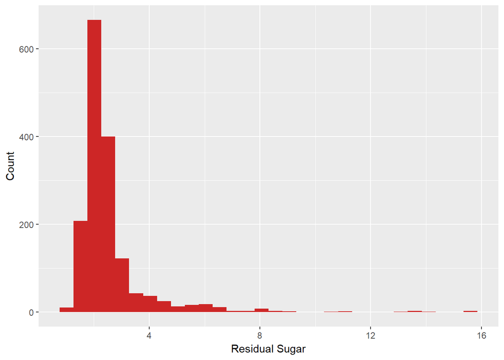

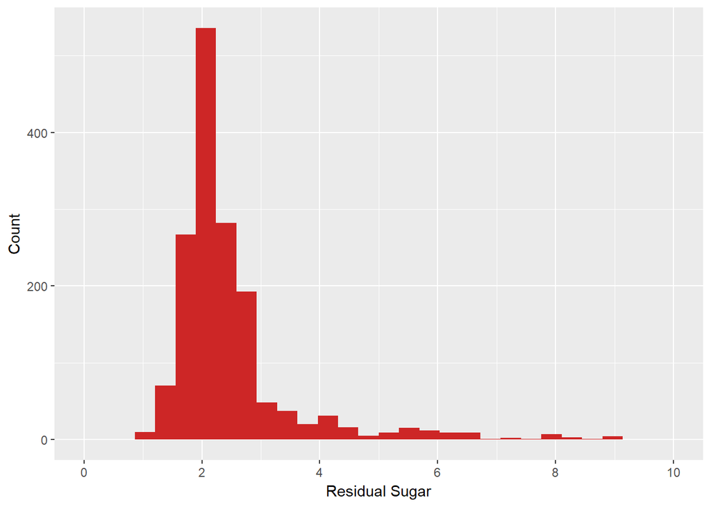

When I first plotted residual sugar, we had a few outliers of relatively sweet wines that came in at over 12g of sugar making this plot a bit difficult to see so I used some limits to get a better view of our distribution. Here we see a positive skew once again with the majority of our points falling between 1 to 3 grams of sugar. We have a mean of 2.539 and a median of 2.200.

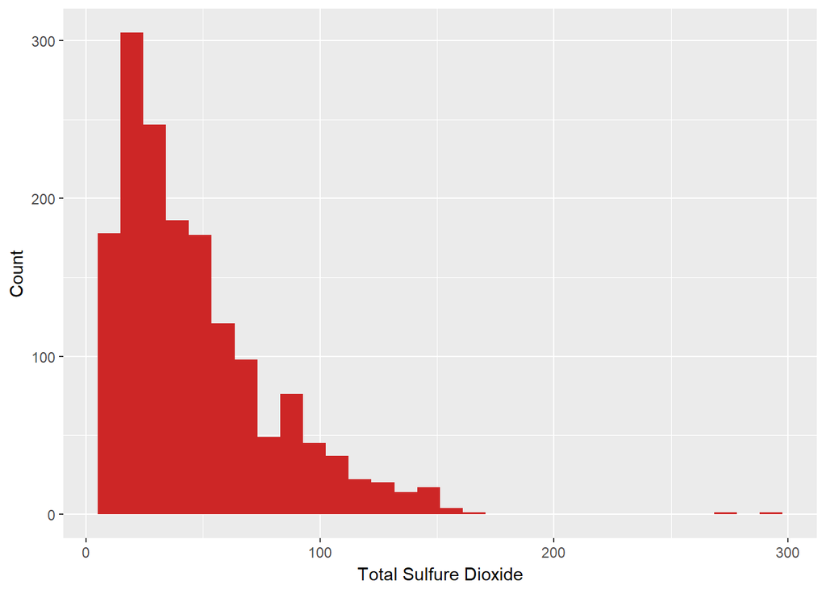

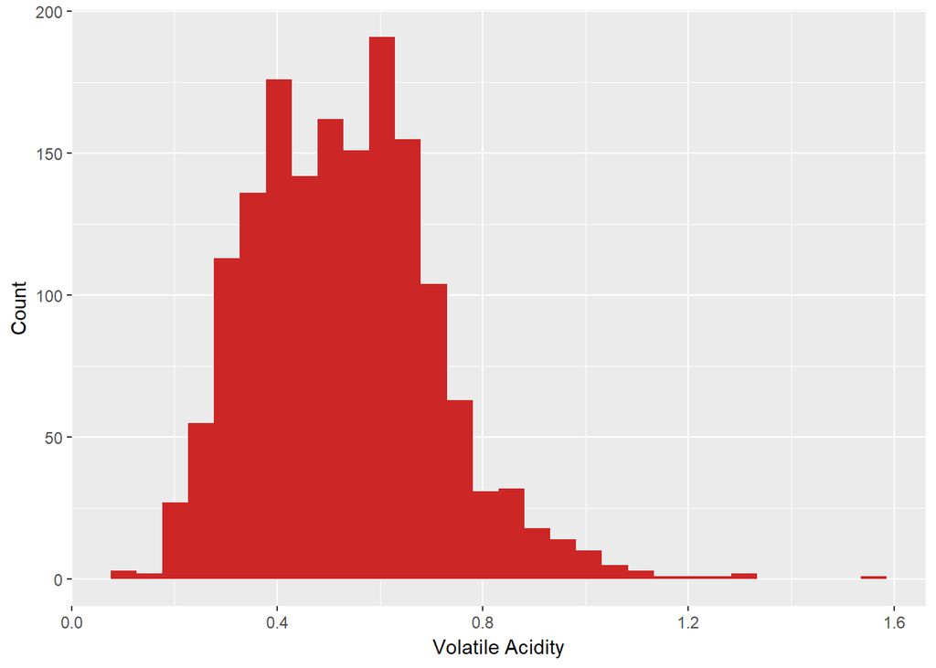

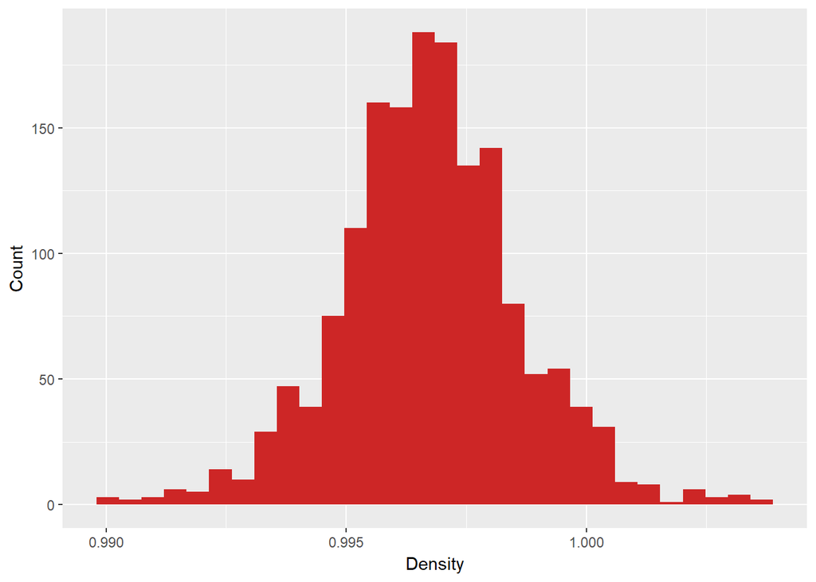

Plotting a few more variables to get a feel for the other variables. Total sulfur dioxide and volatile acidity both have positive skews as well. Our density histogram has a nice normal distribution centered at about 0.997. I’m not exactly sure what affects the density but most wine tends to hang out at about the same spot as water. Not too familiar with what causes changes in density but this difference in density probably won’t give us much insight at surface level.

# Univariate Analysis

### What is/are the main feature(s) of interest in your dataset?

We have various measurements for acid, sulfur, and ph scale related measures. I’ll be focusing most of my analysis on the quality variable and how the other variables affect this. Alcohol percentage is interesting. Does stronger alcohol content mean worse taste? My gut feeling tells me stronger alcohol presence will lead to poor taste and as result lower quality.

### What other features in the dataset do you think will help support your investigation into your feature(s) of interest?

My main goal is to learn what affects the overall quality of the wine. I’m gonna dig to see how the variables available to us are related to quality. I mentioned in the introduction that I think alcohol level, residual sugar, and acidity might be significant.

### Of the features you investigated, were there any unusual distributions? Did you perform any operations on the data to tidy, adjust, or change the form of the data? If so, why did you do this?

I didn’t have to manipulate the data too much since we’re working with a clean data set. I did remove the x variable since we don’t have info on what the id’s correspond to. When creating a histogram for the residual sugar distribution, I used some limits to zoom in on the majority of the distribution. Otherwise it would have been tough to see ranges of our distribution.

# Bivariate Plots Section

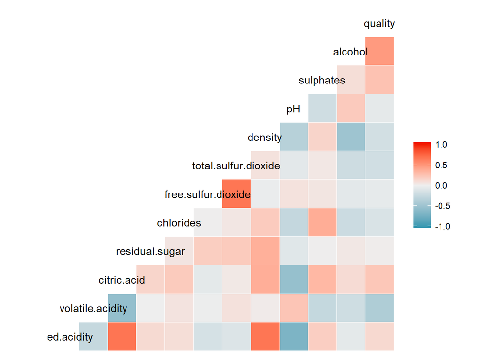

We plot ggcorr to get an idea of our data and we see mostly weak correlations but there are a few low to medium sized correlations. Nothing as strong as we saw with the diamond data set in previous exercises. The strongest correlations I see in relation to wine quality are alcohol, volatile acidity, and sulphates. Other than wine quality, ther are high correlations for citric acid and fixed acidity and volatile acidity.

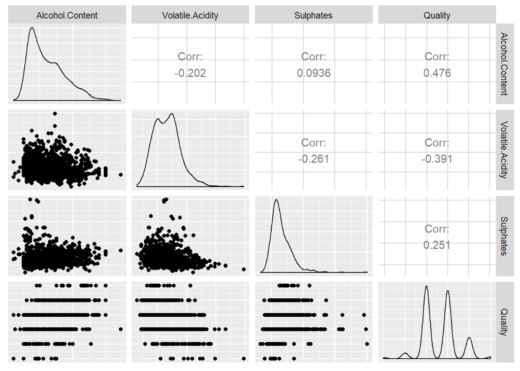

```
##
##  Pearson's product-moment correlation
##
## data:  reds$citric.acid and reds$fixed.acidity
## t = 36.234, df = 1597, p-value < 2.2e-16
## alternative hypothesis: true correlation is not equal to 0
## 95 percent confidence interval:
##  0.6438839 0.6977493
## sample estimates:
##       cor
## 0.6717034
```

```
##
##  Pearson's product-moment correlation
##
## data:  reds$citric.acid and reds$volatile.acidity
## t = -26.489, df = 1597, p-value < 2.2e-16
## alternative hypothesis: true correlation is not equal to 0
## 95 percent confidence interval:
##  -0.5856550 -0.5174902
## sample estimates:
##        cor
## -0.5524957
```

In relation to quality, we get r= 0.476 for alcohol, r = -0.391 for volatile acidity, and r = 0.251 for sulphates. Alcohol correlation is fairly large in effect size so we’ll start investigating that one first. Volatile acidity is moderate and sulphates is more on the small side. We also observed high correlations in the previous ggcorr plot for citric acid in relation to fixed acidity and volatile acidty at 0.67 and -0.55, respectively.

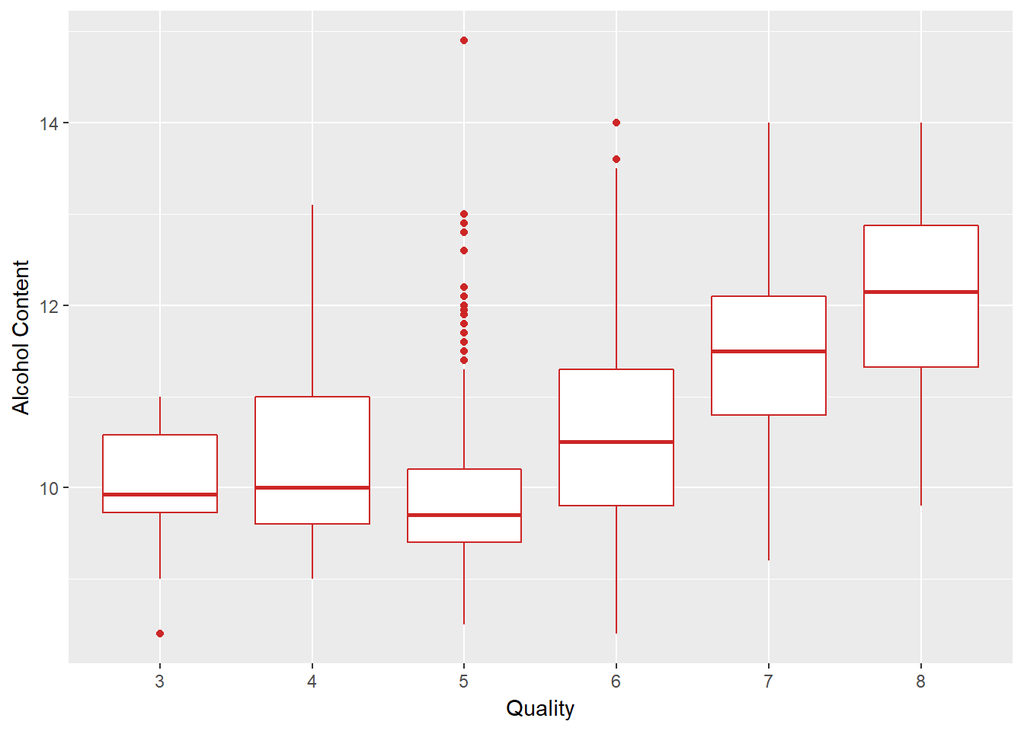

It’s interesting to see quality of wine positively correlated with alcohol. At 0.476 we have a decent correlation. Could higher alcohol content mean better taste or is it a reflection of better brewing methods? Our boxplot here gives us an idea where the averages fall for each quantity value. However, it’s difficult to see the correlation we observed with our initial ggcorr plot. There’s a nice upwards trend of the average alcohol content for quality values starting at 5 to 8. Our first two values of 3 and 4 don’t appear to go with the trend very well.

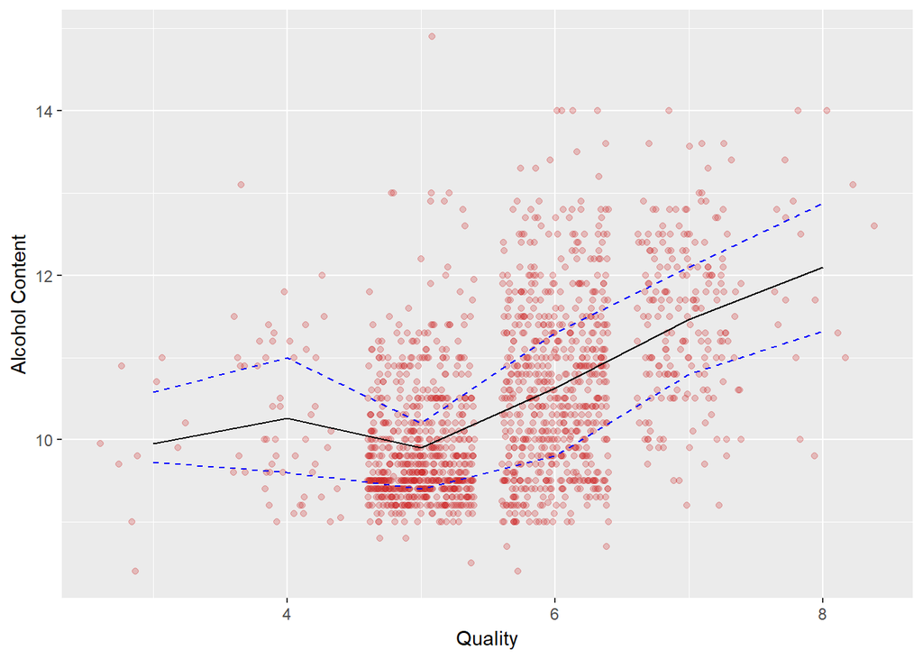

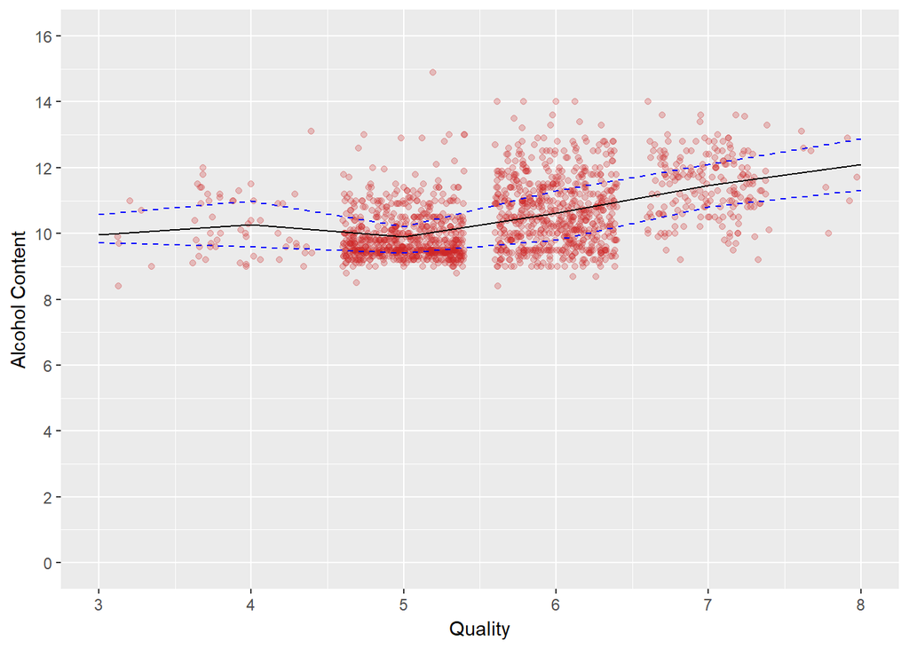

Here we made a scatter plot of quality and alcohol content but we also included some averages to see if we can start seeing a correlation. Adding jitter and alpha better demonstrates the spread near the 5 and 6 values. We see the mean alcohol content hang around 10% at quality 5 and gradually increase to 12% as wine quality increases to 8. There doesn’t seem to be much of a trend with quality ratings below 5.

Our initial plot exaggerates the correlation because our y value for acohol content doesn’t start at 0 so I adjusted to limits to better demonstrate what is going on. We see a bit of a spike and increase at quality rating 6 and higher. However, the correlation of 0.476 looks fairly weak on our plot. Perhaps if we grouped the data into low, medium, and high quality wine we would see a clearer relationship. For now I’ll group the data by quality rating and get a single average for alcohol content at that rating.

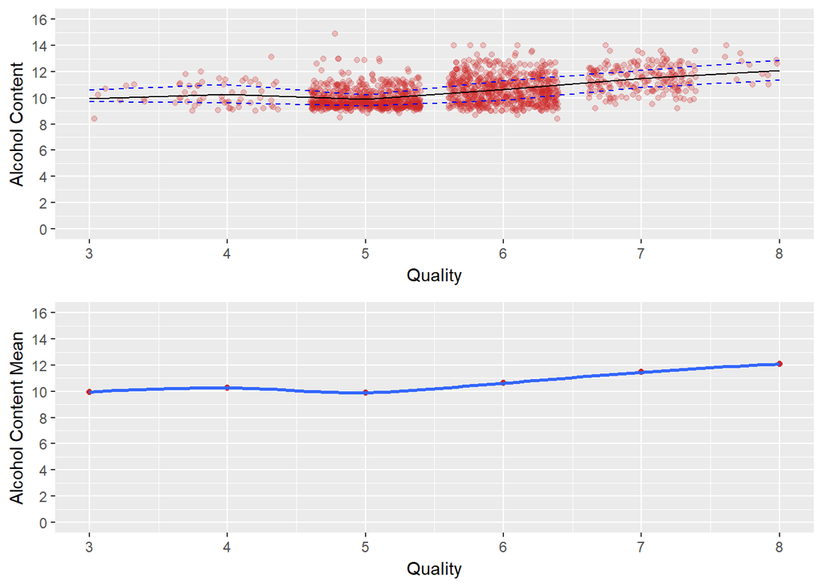

If we clean up our plot to only have average alcohol content, There is a small increase once quality rating reaches 5. If the trend was better represented at the lower ratings of 3 and 4, we could say this is a great correlation but as it is right now it may not be that significant. Let’s explore some additional variables that also had higher values.

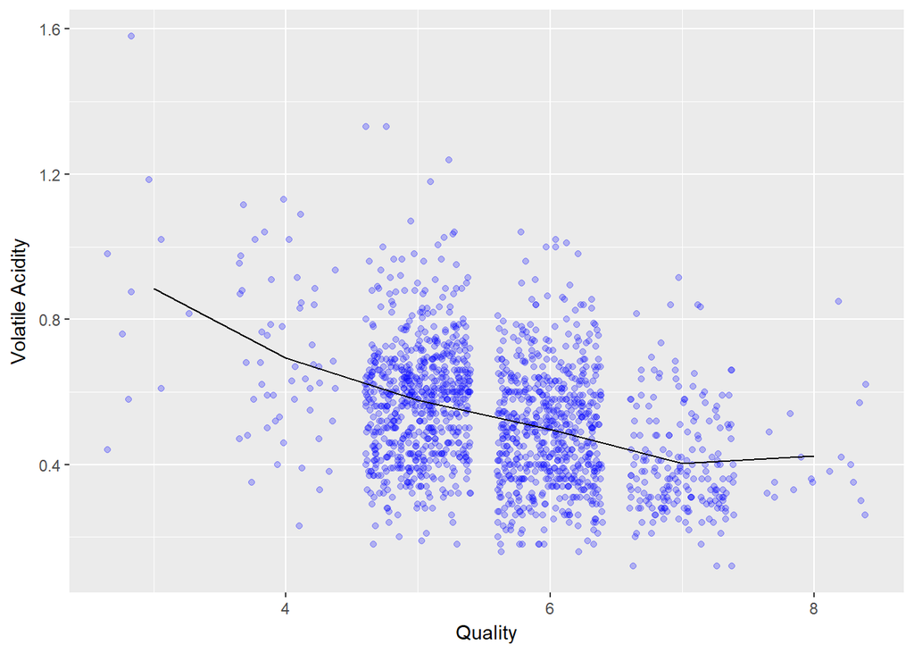

Volatile acidty and quality also had a solid correlation at -0.39. At lower values, ther’s a nice line trending downwards showing that the more volatile acidity in a wine, the lower rating it tends to received. Seems to flat line at about a 7 quality rating.

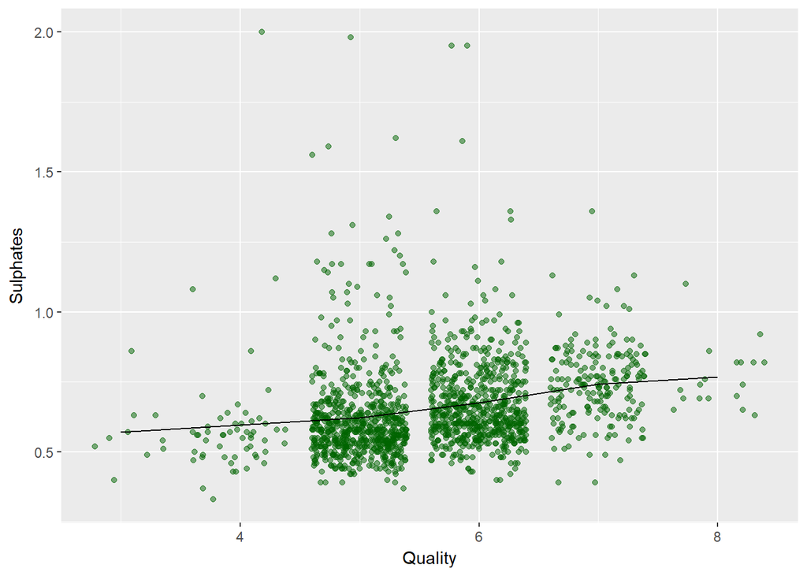

Next I wanted to check out what other correlations looked like. The correlation between sulphates and wine quality was one of the stronger ones for predictding quality of wine at 0.25. The plot itself shows a modest incline of more sulphate presence as wine quality increases. Sulphates are used to preserve wine and keep the flavor fresh longer. Decent reflection of wine making but not a very significant direct impact on wine quality rating.

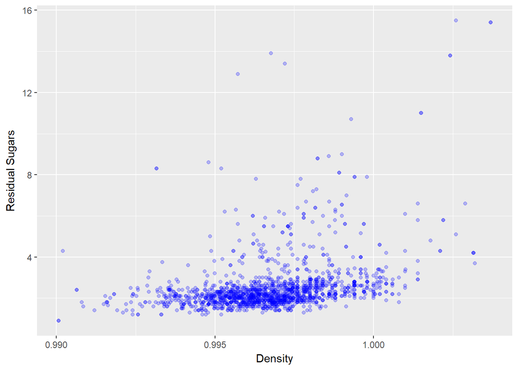

```
##
##  Pearson's product-moment correlation
##
## data:  reds$density and reds$residual.sugar
## t = 15.189, df = 1597, p-value < 2.2e-16
## alternative hypothesis: true correlation is not equal to 0
## 95 percent confidence interval:
##  0.3116908 0.3973835
## sample estimates:
##       cor
## 0.3552834
```

Density and residual sugar was another larger correlation at 0.35. Looking at the scatterplot it’s hard to tell the relation. I’m gonna try inverting the variables to see how that looks.

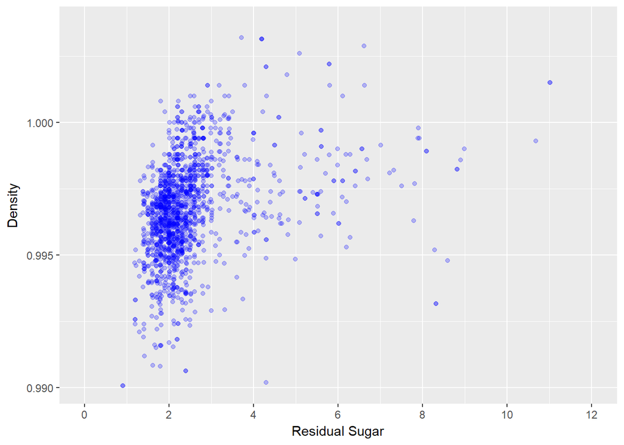

When you put residual sugar on the x-axis and density on the y-axis, we can start seeing a bit more of a trend but its still mostly a cluster. I thought this would be a visible relationship since more of a solid would probably mean higher density. I also include similar limits to when we first looked at residual sugar to leave out some of the high value outliers.

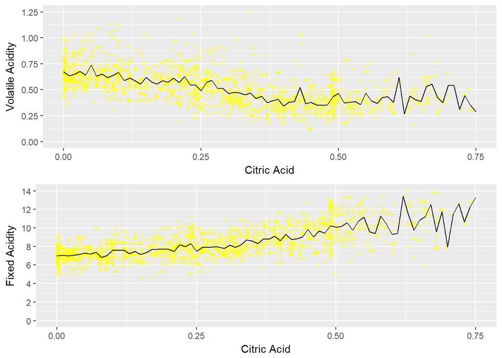

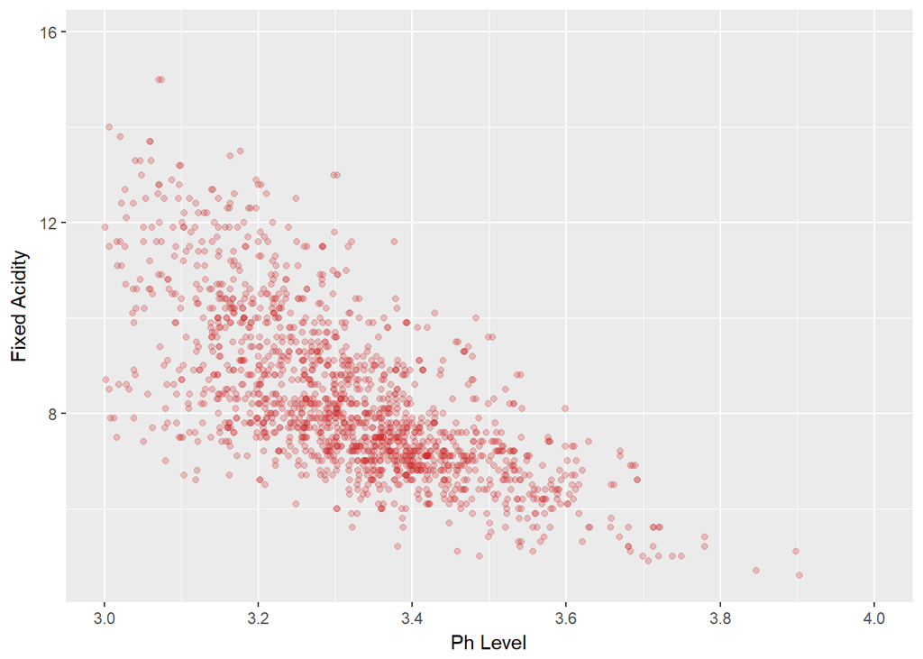

```
##
##  Pearson's product-moment correlation
##
## data:  reds$pH and reds$fixed.acidity
## t = -37.366, df = 1597, p-value < 2.2e-16
## alternative hypothesis: true correlation is not equal to 0
## 95 percent confidence interval:
##  -0.7082857 -0.6559174
## sample estimates:
##        cor
## -0.6829782
```

I explored ph and fixed acidity since it was another strong correlation at -0.68 and its pretty straight forward. More acidity usually means lower pH values. There is a nice downward trend between these two variables.

# Bivariate Analysis

### Talk about some of the relationships you observed in this part of the investigation. How did the feature(s) of interest vary with other features in the dataset?

Volatile acidity and quality was a really interesting one. One the largest negative correlations in our data set. After some quick research, I found out that the primary volatile acid in wine is acetic acid which is associated with the taste and smell of vinegar. This begins to explain the correlation. More volatile acid means more smelly and pungent wine which could lower quality.

After reading more about sulphates(sulphites) in wine, sulphates are used primarily as a preservative to prevent oxidization and keep the wine fresh. This is a reflection of better brewed and treated wines which would indirectly increase the quality of wine over various variables, not just sulphates.

### Did you observe any interesting relationships between the other features (not the main feature(s) of interest)?

Density and residual sugar had a correlation of 0.35 which is the strongest correlation that residual sugar has compared to other variables. Otherwise, residual sugar doesn’t have other significant interactions. This makes sense since red wine tends to have low sugar and isn’t a key component to good wine.

Density also has strong correlations with fixed acidity, and citric acid. These correlations makes sense since density is a measure of content per volume. More sugar or acidic material would make it denser than water.

Citric acid has a positive correlation with fixed acidity and negative correlation with volatile acidity. I’m not an expert on acids so I did some reading. Citric acid added before the fermentation process can turn into acetic acid which is the most common source for volatile acidity and explains the correlation. There is less citric acid because it turns into acetic acid which adds to volatile acidity. If added after the fermentation process, citric acid can complement a specific flavor and also add to its ‘fresh’ flavor.

### What was the strongest relationship you found?

The strongest correlation I found was the negative correlation between pH and fixed acidity, r = -0.68. This one is straight forward since acid levels are on the lower end of the pH scale, 1-6, with neutral being at 7. Most of our wine falls within the 3-4 which is a mild acid.

# Multivariate Plots Section

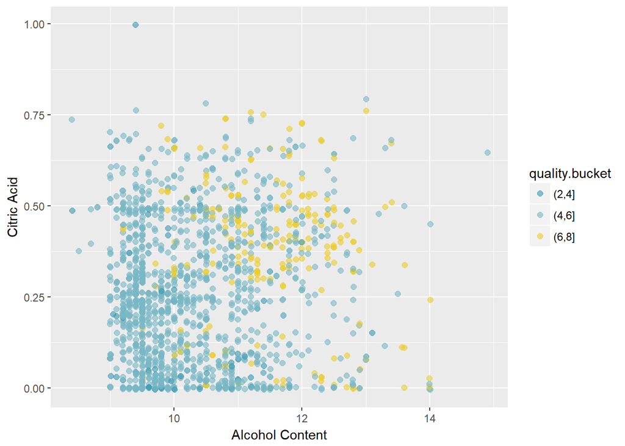

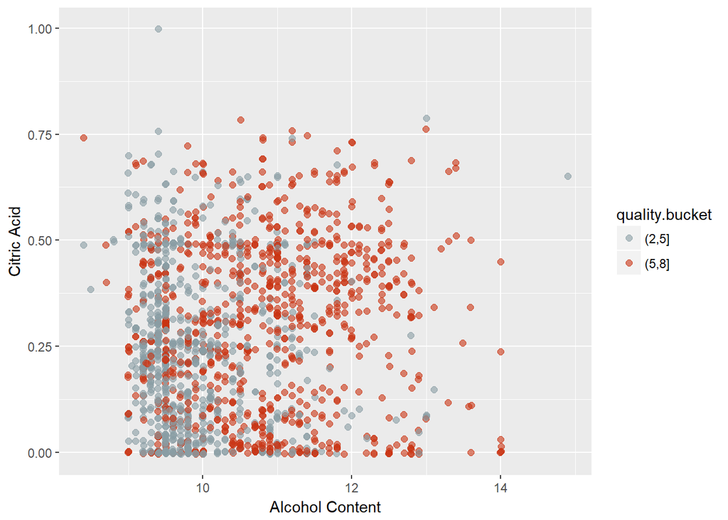

Since we had two peaks right around the middle, 5 and 6 rating, I made buckets to reflect the two sides of the peak and see if the clusters can show any major differences between the two ends of this data set. Here the data is a little bit random but wine with a rating higher than 5 seems to be higher in wine quality making up the majority of our points right of the 11% mark

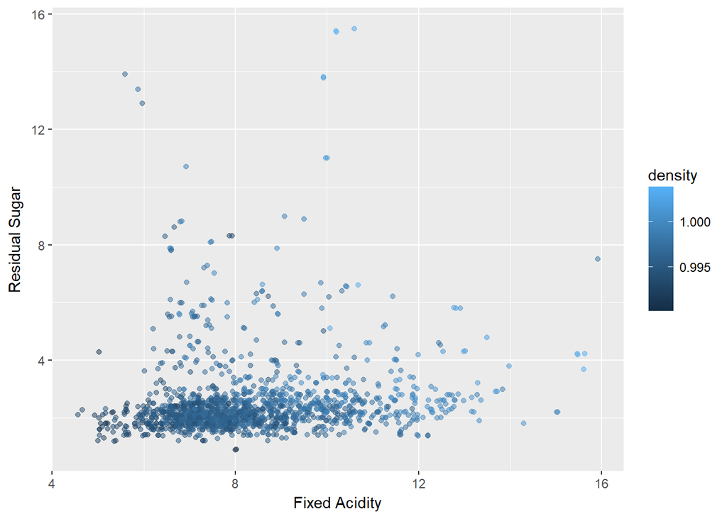

Both residual sugar and fixed acidity were correlated to higher density values. When we plot all three variables, we can see the two correlations compliment each other. Values high in fixed acidity and residual sugar tend to have a lighter shade of blue indicating higher density than the dark blue points Most of the darker blue points hang in the bottom left of our plot indicating lower values in fixed acidity or residual sugar.

```
##
## Calls:
## r1: lm(formula = I(quality) ~ I(alcohol), data = reds)
## r2: lm(formula = I(quality) ~ I(alcohol) + citric.acid, data = reds)
## r3: lm(formula = I(quality) ~ I(alcohol) + citric.acid + volatile.acidity,
##     data = reds)
## r4: lm(formula = I(quality) ~ I(alcohol) + citric.acid + volatile.acidity +
##     sulphates, data = reds)
## r5: lm(formula = I(quality) ~ I(alcohol) + citric.acid + volatile.acidity +
##     sulphates + density, data = reds)
##
## ==========================================================================================
##                          r1            r2            r3            r4            r5
## ------------------------------------------------------------------------------------------
##   (Intercept)           1.875***      1.830***      3.055***      2.646***    -12.504
##                        (0.175)       (0.171)       (0.194)       (0.201)      (11.964)
##   I(alcohol)            0.361***      0.346***      0.314***      0.309***      0.323***
##                        (0.017)       (0.016)       (0.016)       (0.016)       (0.019)
##   citric.acid                         0.730***      0.068        -0.079        -0.155
##                                      (0.090)       (0.103)       (0.104)       (0.120)
##   volatile.acidity                                 -1.343***     -1.265***     -1.301***
##                                                    (0.114)       (0.113)       (0.116)
##   sulphates                                                       0.696***      0.680***
##                                                                  (0.103)       (0.104)
##   density                                                                      15.106
##                                                                               (11.927)
## ------------------------------------------------------------------------------------------
##   R-squared             0.227         0.257         0.317         0.336         0.337
##   adj. R-squared        0.226         0.256         0.316         0.334         0.335
##   sigma                 0.710         0.696         0.668         0.659         0.659
##   F                   468.267       276.595       246.976       201.777       161.803
##   p                     0.000         0.000         0.000         0.000         0.000
##   Log-likelihood    -1721.057     -1688.711     -1621.596     -1599.093     -1598.288
##   Deviance            805.870       773.917       711.603       691.852       691.157
##   AIC                3448.114      3385.421      3253.192      3210.186      3210.576
##   BIC                3464.245      3406.930      3280.078      3242.448      3248.216
##   N                  1599          1599          1599          1599          1599
## ==========================================================================================
```

```
##        fit      lwr      upr
## 1 6.838799 5.542027 8.135572
```

To test out our linear regression model I provided a wine with hypothetical wine descriptors, not real values, to fill out all 5 of the variables I used in my r5 model. Our model predicted that the quality of our hypothetical wine would be about 6.84 with a lower bound of 5.54 and upper bound of 8.14. This seems reasonable since I tried to fill out some hypotheticalvalues that would be rated on the higher end of their respective category. It’s important to remember our low correlation values so I wouldn’t put too much faith on these predictions.

```
##        fit      lwr      upr
## 1 7.035012 5.635479 8.434546
```

I did a real world test by grabbing a bottle of wine from a nearby shop trying to get a bottle high in alcohol. I found a bottle with 14.3% alcohol content. Using my r1 model, just alcohol to predict quality, we get a predicted quality rating of 7.04 which is fairly high, lower 5.64 and upper 8.43. This is fairly reasonable with our limited variable descriptor. The only way to get more info was if I had a chemistry kit to examine sulphates level, acidity, etc. Tasted the wine and I would give it a 6 to 7 myself so I agree with the model in this example. I wouldn’t expect the r1 model to be reliable in all future examples because we’re only using one variable and the correlations are fairly low.

# Multivariate Analysis

### Talk about some of the relationships you observed in this part of the investigation. Were there features that strengthened each other in terms of looking at your feature(s) of interest?

The main takeaway from this project for me is learning how to identify good wine with known variables. After plotting the quality scatter plot with alcohol percentage on the x-axis and citric acid on the y-axis, I saw that if you looked at more than one variable to predict quality, you start seeing some nice patterns and are able to make some more consistent guesses.

### Were there any interesting or surprising interactions between features?

When you group qualities of wine into two groups, one low quality and other high quality, you start to see clusters begin to separate when looking at different variables but there is still a lot of overlap. I’m curious how price as a variable would interact with our observations in this data set. I would guess it would behave similarly as our other variables in this data set which is that it wouldn’t have a strong impact on the quality. Generally more expensive would be better but it wouldn’t be a 1 to 1 correlation.

### OPTIONAL: Did you create any models with your dataset? Discuss the strengths and limitations of your model.

# Final Plots and Summary

### Plot One

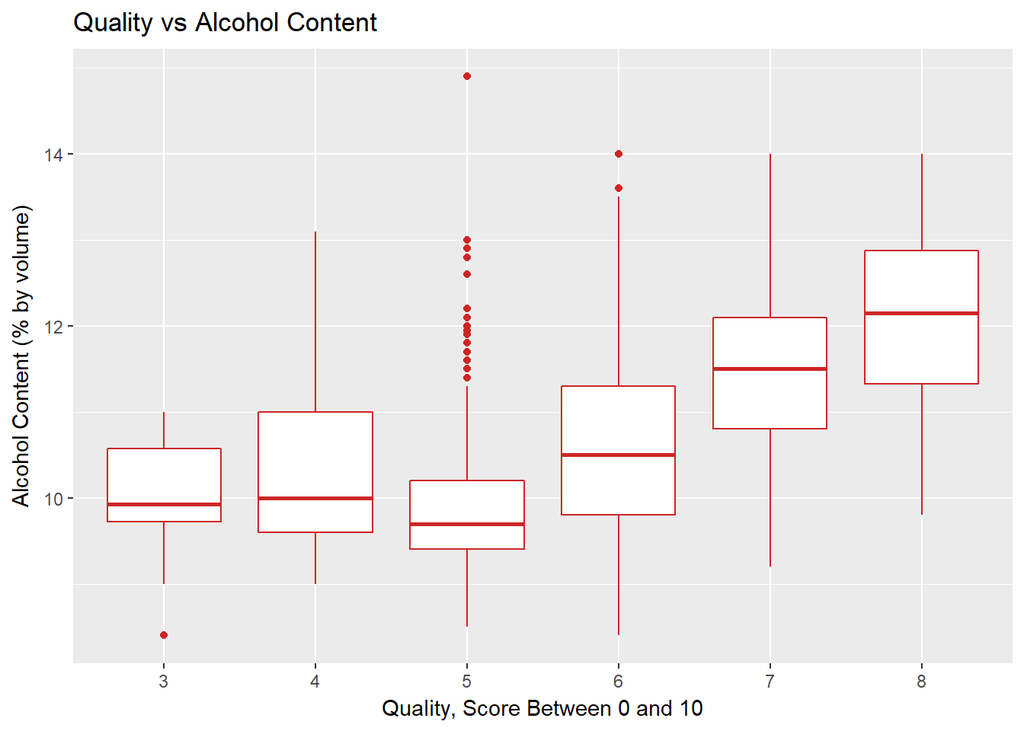

### Description One

This plot was one of the most surprising to me. I normally had associated heavier alcohol content with poor taste but this plot showed a completely opposite trend. It’s a nice and clear plot showing that as alcohol percentage increase, quality also tends to increase. While the trend isn’t clear for values lower than and including 4, there is a positive trend from 5 and upwards.

### Plot Two

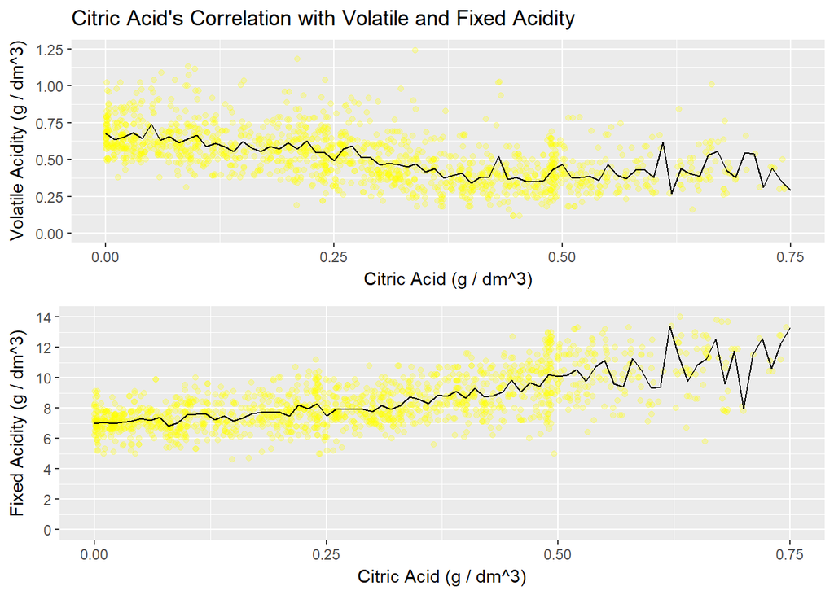

### Description Two

This plot summarizes the interaction between citric acid and fixed/volatile acidity. Citric acid is primarily a fixed acid while acetic acid, it’s counter- part, is primarily a volatile acid. This is because citric acid turns into acetic acid during the fermentation process which would increase the volatile acidity while lowering fixed acidity. There’s an inverse relationship here. More citric acid usually means lower acetic acid and lower volatile acidity.

### Plot Three

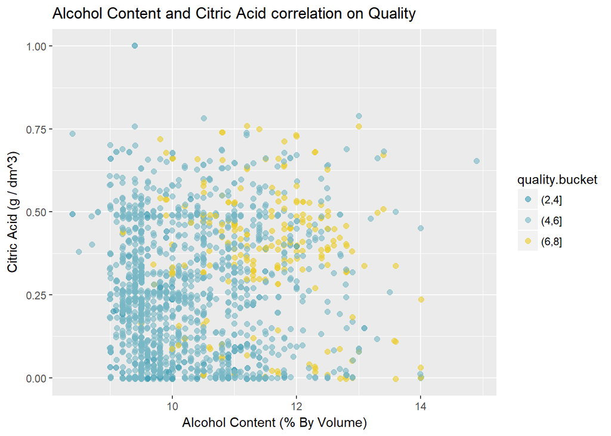

### Description Three

This last plot is a nice summary of my findings. It demonstrates the surprise alcohol and quality correlation while also including the positive effect of citric acid. This plot also separates wine into three tiers, low, middle, and high quality wine. I chose this color palette because it was really easy to see the high quality wines compared to low and medium quality. There is a nice cluster of blues for low and mid quality wine with the yellow clusters showing the high quality wine hanging out in the top right quadrant, indicating that high quality wine generally is high in alcohol content and also high in citric acid compared to other wines. ——

# Reflection

After spending several hours exploring this red wine data set I feel that I’ve learned a lot about wine using my newly acquired EDA skills. I was surprised by the alcohol positive correlation on quality. I learned a bit about the fermentation process and how citric flavors could mean better tasting wine. Some struggles included not knowing where to start. When you’re unfamiliar with a data set, it’s hard to start somewhere. The ggpairs function was super helpful for this since I can get an overview and beging to dig. Another struggle was playing with color palettes. Some times the colors were too similar and data points were clustered too closely together. I spent a lot of time playing with colors, alpha sizes, jitter, etc. It was also tougher than expected to figure out how to manipulate some of these variables to make plots that were easy to extract trends from. Overall I feel like I learned a decent amount about wine and consider myself more of a wine enthusiast. For future projects I would like to strengthen my wrangling skils so I can work with variables a bit more in depth. I had some trouble plotting variables with certain functions because I was accidentally putting quantitative variables into qualitative functions but then the plots wouldn’t come out like I wanted, etc.